# Data workflow to network analysis and value chain

Here the workflor to analyse the answers of the survey obtained during the workshops in Caye Caulkera and Placencia in October 2024.

Import data for summary and inspection

```r
library(readxl)
library(dplyr)
library(ggplot2)
library(MASS) #for data transformation
```

### Import data

```r
Fishery_survey <- read_excel("~/Documents/GitHub_projects/Networks_SSF_NatCap/data/processed/survey_answers.xlsx", sheet = "Fishers")
```

### visually inspection of trends

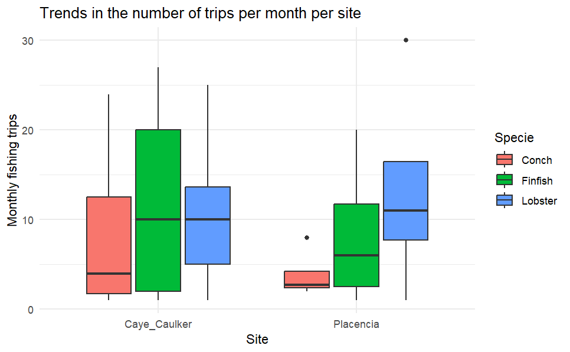

```r
# Trends in the number of trips per month per site
ggplot(Fishery_survey, aes(x = Site, y = Fishing_trips_per_month_season, fill = Specie)) +
  geom_boxplot() +
  theme_minimal() +
  labs(title = "Trends in the number of trips per month per site", y = "Monthly fishing trips", x = "Site")
```

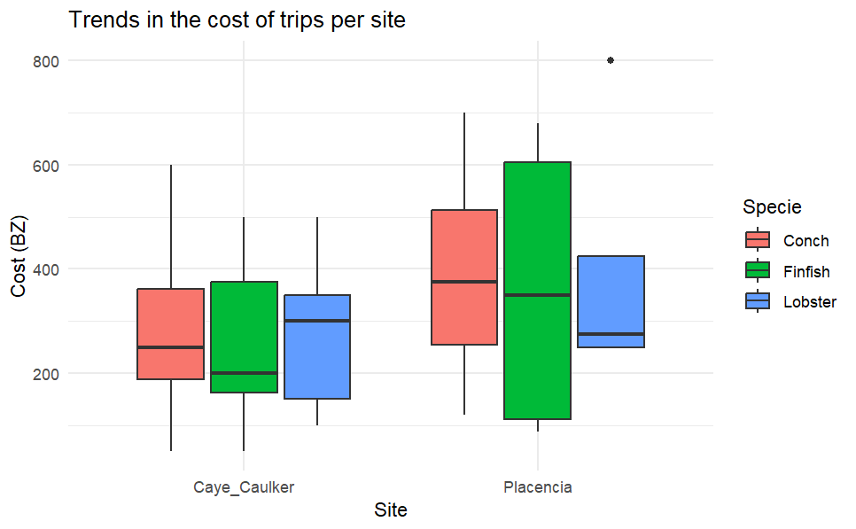

```r
# Trends in the cost of trips per site
ggplot(Fishery_survey, aes(x = Site, y = Fishing_trip_cost, fill = Specie)) +
  geom_boxplot() +
  theme_minimal() +
  labs(title = "Trends in the cost of trips per site", y = "Cost (BZ)", x = "Site")
```

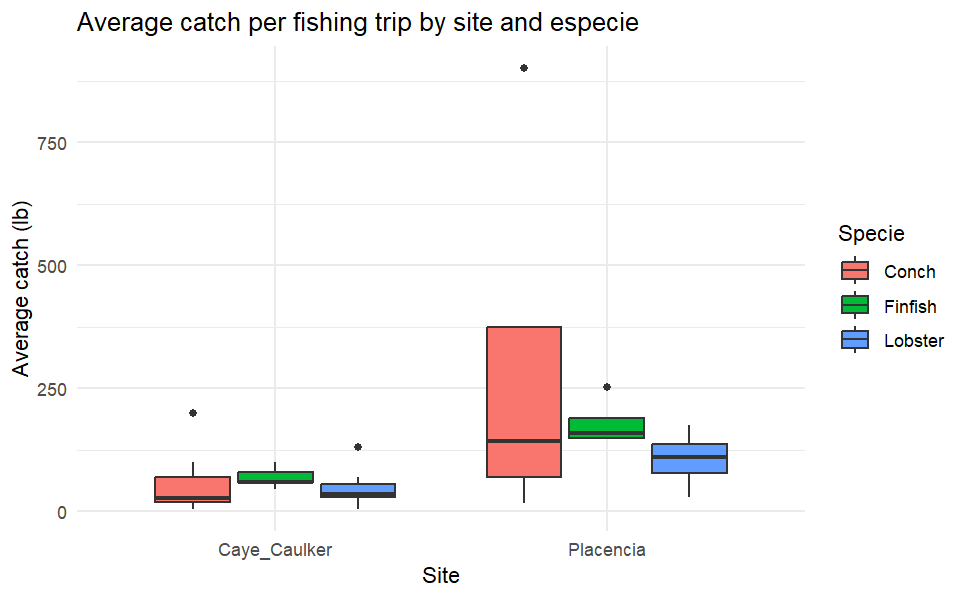

```r
# Trends in the average catch per fishing trips
ggplot(Fishery_survey, aes(x = Site, y = Average_catch_per_trip, fill = Specie)) +
  geom_boxplot() +
  theme_minimal() +
  labs(title = "Average catch per fishing trip by site and especie", y = "Average catch (lb)", x = "Site")
```

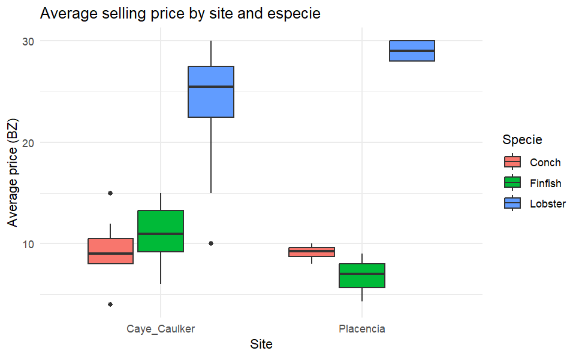

```r
# Trends in the average selling proce per species per site
ggplot(Fishery_survey, aes(x = Site, y = Selling_price, fill = Specie)) +
  geom_boxplot() +
  theme_minimal() +
  labs(title = "Average selling price by site and especie", y = "Average price (BZ)", x = "Site")
```

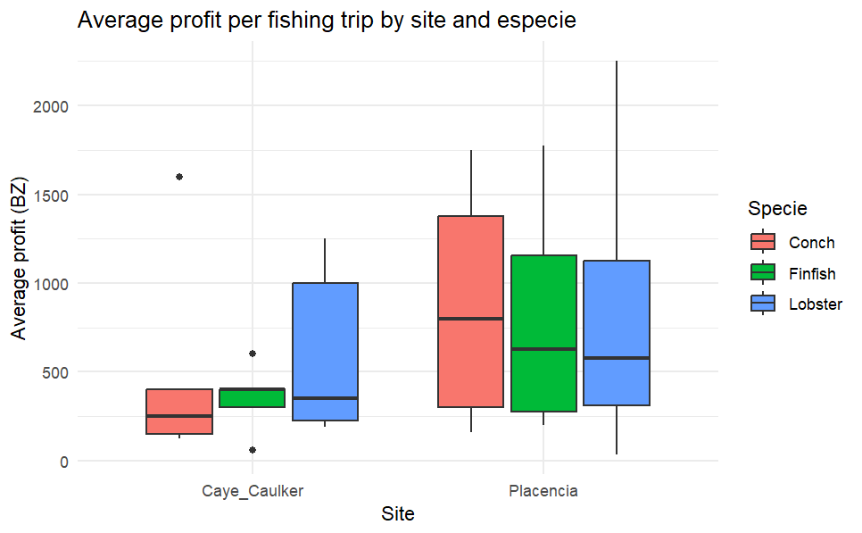

```r
# Trends in the average profit per fishing trips
ggplot(Fishery_survey, aes(x = Site, y = Profit_from_trip, fill = Specie)) +
  geom_boxplot() +
  theme_minimal() +
  labs(title = "Average profit per fishing trip by site and especie", y = "Average profit (BZ)", x = "Site")
```

### Evaluate significant differences between the factors Site and Specie

Check for Missing Data

```r
colSums(is.na(Fishery_survey))
```

```
                          Site                             ID
                             0                              0
                        Gender                      Ethnicity
                             8                              8
                     Age_group                         Specie
                             7                              0
             Fishing_gear_used                Own_vessel_gear
                             1                              2
                  Fishing_zone Fishing_trips_per_month_season
                            14                              8
            Hours_fishing_trip              Fishing_trip_cost
                             6                              8
        Average_catch_per_trip                  Selling_price
                            14                             13
              Profit_from_trip             To_whom_sell_catch
                            19                              8
```

Filter rows with no missing data for specific variables

```r
filtered_data <- Fishery_survey %>%
  filter(
  !is.na(Fishing_trips_per_month_season) &
  !is.na(Average_catch_per_trip) &
  !is.na(Selling_price) &
  !is.na(Average_catch_per_trip) &
  !is.na(Profit_from_trip)
  )
```

Evaluate Differences: Non-Parametric Tests Kruskal-Wallis Test (for more than two groups)

```r
# Variables to analyze
fishery_vars <- c("Fishing_trips_per_month_season",
                  "Average_catch_per_trip",
                  "Selling_price",
                  "Average_catch_per_trip",
                  "Profit_from_trip")

# Apply Kruskal-Wallis test for each variable
results <- lapply(fishery_vars, function(var) {
  list(
    variable = var,
    by_site = kruskal.test(as.formula(paste(var, "~ Site")), data = filtered_data),
    by_specie = kruskal.test(as.formula(paste(var, "~ Specie")), data = filtered_data)
  )
})

# Print results
results
```

```
[[1]]
[[1]]$variable
[1] "Fishing_trips_per_month_season"

[[1]]$by_site

    Kruskal-Wallis rank sum test

data:  Fishing_trips_per_month_season by Site
Kruskal-Wallis chi-squared = 0.91866, df = 1, p-value = 0.3378


[[1]]$by_specie

    Kruskal-Wallis rank sum test

data:  Fishing_trips_per_month_season by Specie
Kruskal-Wallis chi-squared = 2.7106, df = 2, p-value = 0.2579



[[2]]
[[2]]$variable
[1] "Average_catch_per_trip"

[[2]]$by_site

    Kruskal-Wallis rank sum test

data:  Average_catch_per_trip by Site
Kruskal-Wallis chi-squared = 4.5197, df = 1, p-value = 0.03351


[[2]]$by_specie

    Kruskal-Wallis rank sum test

data:  Average_catch_per_trip by Specie
Kruskal-Wallis chi-squared = 1.4202, df = 2, p-value = 0.4916

```

[output cut: 47 more lines]

```

[[5]]$by_site

    Kruskal-Wallis rank sum test

data:  Profit_from_trip by Site
Kruskal-Wallis chi-squared = 1.3749, df = 1, p-value = 0.241


[[5]]$by_specie

    Kruskal-Wallis rank sum test

data:  Profit_from_trip by Specie
Kruskal-Wallis chi-squared = 0.21805, df = 2, p-value = 0.8967
```

### Value chain methods

This analysis focuses on the actors from a market perspective, stressing the importance of value addition in each step, and seeks to understand how value is created and shared among chain participants.

Steps: 1. Estimated the total fishery weight and landed value

- Estimated catch per fishing trip/sp * num of licenced fishers in Placencia and Caye Caulker

### 1. Estimated the total fishery weight and landed value

During the survey, fishers reported the average catch they get from a fishing trip (CPUE in terms of pounds of target species per fishing trip) and the number of fishing trips they perform monthly during the fishery season. With these values, it is possible to estimate the total catch each fisher get during the season. Then, we can use the average individual catch per season to estimate the total catch by multiply that value by the total number of lincenced fishers in Placencia and Caye Caulker.

```r
# calculate the total catch for each fisher over an 8-month fishing season

# Filter data to exclude rows with missing values
Fishery_clean <- Fishery_survey %>%
  filter(!is.na(Average_catch_per_trip), !is.na(Fishing_trips_per_month_season))

# Calculate total catch for each fisher in an 8-month season
seasonal_catch <- Fishery_clean %>%
  mutate(
    Monthly_Catch = Average_catch_per_trip * Fishing_trips_per_month_season,
    Catch_Season = Monthly_Catch * 8,
    Total_output_BZ =  Catch_Season * Selling_price,
    Total_effort_season = Fishing_trips_per_month_season * 8,
    Intermediate_inputs = Total_effort_season * Fishing_trip_cost,
    Net_profit = Total_output_BZ - Intermediate_inputs
  )

# Display the results
print(seasonal_catch)
```

| Site | ID | Gender | Ethnicity | Age_group | Specie | Fishing_gear_used | Own_vessel_gear | Fishing_zone | Fishing_trips_per_month_season | Hours_fishing_trip | Fishing_trip_cost | Average_catch_per_trip | Selling_price | Profit_from_trip | To_whom_sell_catch | Monthly_Catch | Catch_Season | Total_output_BZ | Total_effort_season | Intermediate_inputs | Net_profit |
| --- | --- | --- | --- | --- | --- | --- | --- | --- | --- | --- | --- | --- | --- | --- | --- | --- | --- | --- | --- | --- | --- |
| Caye_Caulker | Male_1 | Male | Mestizo | >55 | Lobster | Shade and Hook stick | Yes | 1 | 4.0 | 8.0 | 100.0 | 27.50 | 27.500000 | 189.06 | Restaurants | 110.0 | 880 | 24200 | 32 | 3200 | 21000 |
| Caye_Caulker | F_5 | Female | Mestizo | 25 - 34 | Lobster | Shade and Lobster trap | Yes | 1 | 14.0 | 8.0 | 300.0 | 70.00 | 15.000000 | NA | Cooperative Northern | 980.0 | 7840 | 117600 | 112 | 33600 | 84000 |
| Caye_Caulker | SC16 | Male | Creole | 45 - 54 | Lobster | Shade and Lobster trap | Yes | NA | 12.5 | 7.0 | 200.0 | 30.00 | 27.500000 | 400.00 | Restaurants | 375.0 | 3000 | 82500 | 100 | 20000 | 62500 |
| Caye_Caulker | NA_1 | NA | NA | NA | Lobster | Shade and Lobster trap | Yes | 1 and 6 | 20.0 | 6.0 | 500.0 | 40.00 | 25.000000 | 300.00 | Cooperative, restaurants | 800.0 | 6400 | 160000 | 160 | 80000 | 80000 |
| Caye_Caulker | Female_1 | Female | Mestizo, Creole | 25 - 34 | Lobster | Shade | Yes | NA | 5.0 | 2.0 | 350.0 | 4.50 | NA | 200.00 | NA | 22.5 | 180 | NA | 40 | 14000 | NA |
| Caye_Caulker | Male_2 | Male | Creole | 45 - 54 | Lobster | Jamo | Yes | 3 and 4 | 10.0 | 24.0 | 300.0 | 50.00 | 30.000000 | 1200.00 | Restaurants | 500.0 | 4000 | 120000 | 80 | 24000 | 96000 |
| Caye_Caulker | NA_3 | NA | NA | NA | Lobster | Shade | Yes | NA | 25.0 | 5.0 | 100.0 | 30.00 | 26.000000 | NA | Cooperative | 750.0 | 6000 | 156000 | 200 | 20000 | 136000 |
| Caye_Caulker | Male_3 | Male | Mestizo, Maya | 25 - 34 | Lobster | Shade | No | 1 and 6 | 10.0 | 6.0 | 500.0 | 131.25 | 25.000000 | 1250.00 | Cooperative and restaurants | 1312.5 | 10500 | 262500 | 80 | 40000 | 222500 |
| Placencia | PLA 24 | NA | NA | NA | Lobster | Other | Yes | 3 and 4 | 10.0 | 30.0 | 800.0 | 125.00 | 30.000000 | 2250.00 | Restaurants | 1250.0 | 10000 | 300000 | 80 | 64000 | 236000 |
| Placencia | PLA 1 | Male | Creole | 45 - 54 | Lobster | Shade | Yes | 3 and 4 | 1.0 | 8.0 | 250.0 | 95.00 | 28.000000 | 750.00 | Restaurant | 95.0 | 760 | 21280 | 8 | 2000 | 19280 |

[output cut: 22 more lines]

```r
# Calculate the average and standard deviation of total catch per season by species
catch_stats <- seasonal_catch %>%
  group_by(Site, Specie) %>%
  summarize(
    Average_Catch = mean(Catch_Season, na.rm = TRUE),
    SD_Catch = sd(Catch_Season, na.rm = TRUE),
    Average_Profit = mean(Net_profit, na.rm = TRUE),
    SD_Profit = sd(Net_profit, na.rm = TRUE)
  )
# Display the results
print(catch_stats)
```

| Site | Specie | Average_Catch | SD_Catch | Average_Profit | SD_Profit |
| --- | --- | --- | --- | --- | --- |
| Caye_Caulker | Conch | 2610.286 | 2444.628 | 8864.00 | 24407.63 |
| Caye_Caulker | Finfish | 3392.000 | 2940.258 | 29620.00 | 19143.29 |
| Caye_Caulker | Lobster | 4850.000 | 3511.255 | 100285.71 | 64058.47 |
| Placencia | Conch | 6330.000 | 7957.780 | 47490.00 | 71595.72 |
| Placencia | Finfish | 10555.000 | 9756.726 | 54853.33 | 42513.16 |
| Placencia | Lobster | 13910.000 | 19139.136 | 376780.00 | 557046.51 |

Estimate the total catch in both places by multiply the average catch per fisher during the season by the total number of lisenced fishers (data from Updated list for WWF Sept 2024).

Caye Caulker: 197 fishers

Placencia: 151 fishers

```r
# Multiply Average_Catch based on Site
Total_catch <- catch_stats %>%
  mutate(Total_Catch = ifelse(Site == "Caye_Caulker", Average_Catch * 197,
                                ifelse(Site == "Placencia", Average_Catch * 151)))

# Display the updated data frame
print(Total_catch)
```

[output not shown]